# real_estate_market_analysis

## Описание проекта

В моем распоряжении данные сервиса Яндекс Недвижимость — архив объявлений за несколько лет о продаже квартир в Санкт-Петербурге и соседних населённых пунктах.

Задача — выполнить предобработку данных и изучить их, чтобы найти интересные особенности и зависимости, которые существуют на рынке недвижимости.

О каждой квартире в базе содержится два типа данных: добавленные пользователем и картографические. Например, к первому типу относятся площадь квартиры, её этаж и количество балконов, ко второму — расстояния до центра города, аэропорта и ближайшего парка.

# Шаг 1. Открытие файла

```python
import pandas as pd
import matplotlib.pyplot as plt
import os
```

```python
def read_file(file_name):
    path1 = os.path.join('/datasets', file_name)
    path2 = os.path.join(file_name)
    if os.path.exists(path1):
        data = pd.read_csv(path1, sep='\t')
        return data
    elif os.path.exists(path2):
        data = pd.read_csv(path2, sep='\t')
        return data
    else:
        print('File is not found')
```

```python
data = read_file('real_estate_data.csv')
```

```python
data.head()
```

|  | total_images | last_price | total_area | first_day_exposition | rooms | ceiling_height | floors_total | living_area | floor | is_apartment | ... | kitchen_area | balcony | locality_name | airports_nearest | cityCenters_nearest | parks_around3000 | parks_nearest | ponds_around3000 | ponds_nearest | days_exposition |
| --- | --- | --- | --- | --- | --- | --- | --- | --- | --- | --- | --- | --- | --- | --- | --- | --- | --- | --- | --- | --- | --- |
| 0 | 20 | 13000000.0 | 108.0 | 2019-03-07T00:00:00 | 3 | 2.70 | 16.0 | 51.0 | 8 | NaN | ... | 25.0 | NaN | Санкт-Петербург | 18863.0 | 16028.0 | 1.0 | 482.0 | 2.0 | 755.0 | NaN |
| 1 | 7 | 3350000.0 | 40.4 | 2018-12-04T00:00:00 | 1 | NaN | 11.0 | 18.6 | 1 | NaN | ... | 11.0 | 2.0 | посёлок Шушары | 12817.0 | 18603.0 | 0.0 | NaN | 0.0 | NaN | 81.0 |
| 2 | 10 | 5196000.0 | 56.0 | 2015-08-20T00:00:00 | 2 | NaN | 5.0 | 34.3 | 4 | NaN | ... | 8.3 | 0.0 | Санкт-Петербург | 21741.0 | 13933.0 | 1.0 | 90.0 | 2.0 | 574.0 | 558.0 |
| 3 | 0 | 64900000.0 | 159.0 | 2015-07-24T00:00:00 | 3 | NaN | 14.0 | NaN | 9 | NaN | ... | NaN | 0.0 | Санкт-Петербург | 28098.0 | 6800.0 | 2.0 | 84.0 | 3.0 | 234.0 | 424.0 |
| 4 | 2 | 10000000.0 | 100.0 | 2018-06-19T00:00:00 | 2 | 3.03 | 14.0 | 32.0 | 13 | NaN | ... | 41.0 | NaN | Санкт-Петербург | 31856.0 | 8098.0 | 2.0 | 112.0 | 1.0 | 48.0 | 121.0 |

5 rows × 22 columns

```python
data.info()
```

```
<class 'pandas.core.frame.DataFrame'>
RangeIndex: 23699 entries, 0 to 23698
Data columns (total 22 columns):
 #   Column                Non-Null Count  Dtype
---  ------                --------------  -----
 0   total_images          23699 non-null  int64
 1   last_price            23699 non-null  float64
 2   total_area            23699 non-null  float64
 3   first_day_exposition  23699 non-null  object
 4   rooms                 23699 non-null  int64
 5   ceiling_height        14504 non-null  float64
 6   floors_total          23613 non-null  float64
 7   living_area           21796 non-null  float64
 8   floor                 23699 non-null  int64
 9   is_apartment          2775 non-null   object
 10  studio                23699 non-null  bool
 11  open_plan             23699 non-null  bool
 12  kitchen_area          21421 non-null  float64
 13  balcony               12180 non-null  float64
 14  locality_name         23650 non-null  object
 15  airports_nearest      18157 non-null  float64
 16  cityCenters_nearest   18180 non-null  float64
 17  parks_around3000      18181 non-null  float64
 18  parks_nearest         8079 non-null   float64
 19  ponds_around3000      18181 non-null  float64
 20  ponds_nearest         9110 non-null   float64
 21  days_exposition       20518 non-null  float64
dtypes: bool(2), float64(14), int64(3), object(3)
memory usage: 3.7+ MB
```

### Построим гистрограммы для числовых столбцов таблицы

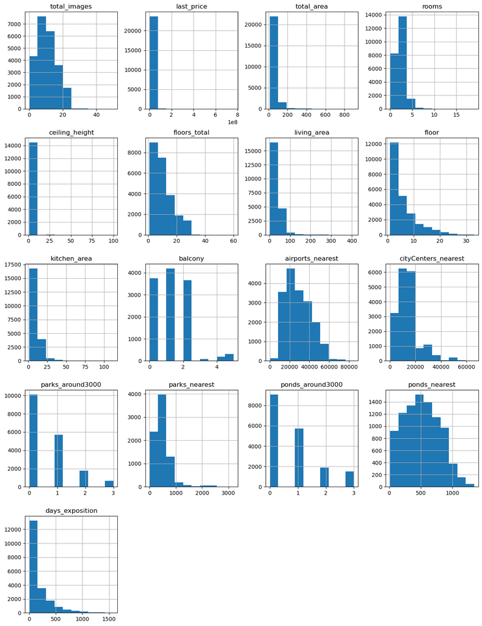

```python
data.hist(figsize=(15, 20))
plt.show()
```

# Шаг 2. Предобработка данных

### Рассмотрим пропущенные значения в столбцах:

- **Высота потолков**. Пропуски в данном столбце скорее всего связаны с тем, что продавец либо сам не знает значение, либо просто не внес. Данное значение можно заменить **на среднее**
- **Всего этажей**. Пропуски также носят случайный характер, заменим их на **медиану**.
- **Жилая площадь**. Скорее всего пропуски носят случайный характер, так как в жилой недвижимости жилая площадь не может равняться нулю, заменим пустые значения **на медиану, соразмерной количеству комнат**.
- **Апартамент**. В данном столбце представлены булевы значения. **Заменим пропуски на False**.
- **Площадь кухни**. Аналогично с жилой недвижимостью, заменим пустые значения **на медиану, соразмерной количеству комнат**. В исключительных случаях кухня может отсутствовать либо мы установили 0, таких строк немного, поэтому на выборку они не повлияют.
- **Балкон**. Вероятно пропущенные значения говорят об отсутствии балкона, **заменим пропуски на ноль**.
- **Парки в радиусе 3000**. Пропущенные значения свидетельствуют об отсутствии парков, **заменим пропуски на ноль**.
- **Пруды в радиусе 3000**. Пропущенные значения свидетельствуют об отсутствии прудов, **заменим пропуски на ноль**.
- **Остальные столбцы**. Пропущенные значения в остальных столбцах будет некорректно заменить средним или нулем, необходимо сверяться с картой либо, как в случае с "days_exposition", у нас не хватает данных, поэтому **оставим пропуски, как есть**.

```python
data['ceiling_height'] = data['ceiling_height'].fillna(data['ceiling_height'].mean()).round(2)
```

В столбце "Всего этажей" было всего 86 пропусков, удаление строк с пропусками в данном столбце никак не повлияет на выборку и результаты исследования, поэтому сделаем это.

```python
data = data.dropna(subset=['floors_total'])
```

```python
data = data.reset_index(drop=True)
```

```python
for room in data['rooms'].unique():
    data.loc[(data['living_area'].isna()) & (data['rooms'] == room), 'living_area'] =\
    data.loc[data['rooms'] == room, 'living_area'].median()
```

Несмотря на то, что мы брали медиану, соотнося количество комнат, у нас появилось 29 строк, в которых жилая площадь больше общей, что невозможно, поэтому удалим данные строки

```python
data = data.loc[data['total_area'] > data['living_area']]
```

```python
data.loc[data['is_apartment'].isna(), 'is_apartment'] = False
```

```python
for room2 in data['rooms'].unique():
    data.loc[(data['kitchen_area'].isna()) & (data['rooms'] == room2), 'kitchen_area'] =\
    data.loc[data['rooms'] == room2, 'kitchen_area'].median()
```

Установим значение 0 там, где 0 комнат.

В 272 строках жилая и кухонная площадь дают в сумме величину, превышающую общую, удалим их.

```python
data.loc[data['rooms'] == 0, 'kitchen_area'] = 0
```

```python
data = data.loc[data['total_area'] > data['living_area'] + data['kitchen_area']]
```

```python
data['balcony'] = data['balcony'].fillna(0)
```

```python
data['parks_around3000'] = data['parks_around3000'].fillna(0)
```

```python
data['ponds_around3000'] = data['ponds_around3000'].fillna(0)
```

### Замена типа данных в столбцах:

- **Дата выставления объявления**. Изменим тип данных на **datetime**.
- **Количество этажей**. Не может быть дробным, изменим на **int**.
- **Апартамент**. Изменим значение на **bool**.
- **Балкон**. Не может быть дробным, изменим на **int**.
- **Парки и пруды в радиусе 3000**. Не может быть дробным, изменим на **int**.
- **Остальные категории**. Нет необходимости заменять или не можем из-за того, что есть пропущенные значения.

```python
data['first_day_exposition'] = pd.to_datetime(data['first_day_exposition'], format='%Y-%m-%dT%H:%M:%S')
```

```python
data['floors_total'] = data['floors_total'].astype('int')
```

```python
data['is_apartment'] = data['is_apartment'].astype('bool')
```

```python
data['balcony'] = data['balcony'].astype('int')
```

```python
data['parks_around3000'] = data['parks_around3000'].astype('int')
```

```python
data['ponds_around3000'] = data['ponds_around3000'].astype('int')
```

### Устранение неявных дубликатов

1. Найдем уникальные названия
2. Создадим датафрейм со столбцом замены
3. Создадим цикл для замены названий-дубликатов

```python
data['locality_name'].unique()
```

```
array(['Санкт-Петербург', 'посёлок Шушары', 'городской посёлок Янино-1',
       'посёлок Парголово', 'посёлок Мурино', 'Ломоносов', 'Сертолово',
       'Петергоф', 'Пушкин', 'деревня Кудрово', 'Коммунар', 'Колпино',
       'поселок городского типа Красный Бор', 'Гатчина', 'поселок Мурино',
       'деревня Фёдоровское', 'Выборг', 'Кронштадт', 'Кировск',
       'деревня Новое Девяткино', 'посёлок Металлострой',
       'посёлок городского типа Лебяжье',
       'посёлок городского типа Сиверский', 'поселок Молодцово',
       'поселок городского типа Кузьмоловский',
       'садовое товарищество Новая Ропша', 'Павловск',
       'деревня Пикколово', 'Всеволожск', 'Волхов', 'Кингисепп',
       'Приозерск', 'Сестрорецк', 'деревня Куттузи', 'посёлок Аннино',
       'поселок городского типа Ефимовский', 'посёлок Плодовое',
       'деревня Заклинье', 'поселок Торковичи', 'поселок Первомайское',
       'Красное Село', 'посёлок Понтонный', 'Сясьстрой', 'деревня Старая',
       'деревня Лесколово', 'Сланцы', 'село Путилово', 'Ивангород',
       'Мурино', 'Шлиссельбург', 'Никольское', 'Зеленогорск',
       'Сосновый Бор', 'поселок Новый Свет', 'деревня Оржицы',
       'деревня Кальтино', 'Кудрово', 'поселок Романовка',
       'посёлок Бугры', 'поселок Бугры', 'поселок городского типа Рощино',
       'Кириши', 'Луга', 'Волосово', 'Отрадное', 'село Павлово',
       'поселок Оредеж', 'село Копорье',
       'посёлок городского типа Красный Бор', 'посёлок Молодёжное',
       'посёлок Победа', 'деревня Нурма',
       'поселок городского типа Синявино', 'Тосно', 'посёлок Новый Свет',
       'посёлок городского типа Кузьмоловский', 'посёлок Стрельна',
       'Бокситогорск', 'посёлок Александровская', 'деревня Лопухинка',
       'Пикалёво', 'поселок Терволово',
       'поселок городского типа Советский', 'Подпорожье',
       'посёлок Петровское', 'посёлок городского типа Токсово',
       'поселок Сельцо', 'посёлок городского типа Вырица',
       'деревня Кипень', 'деревня Келози', 'деревня Вартемяги',
       'посёлок Тельмана', 'поселок Севастьяново',
       'городской поселок Большая Ижора', 'Тихвин', nan,
       'городской посёлок Павлово', 'деревня Агалатово',
       'посёлок Новогорелово', 'городской посёлок Лесогорский',
       'деревня Лаголово', 'поселок Цвелодубово',
       'поселок городского типа Рахья', 'поселок городского типа Вырица',
       'деревня Белогорка', 'поселок Заводской',
       'городской посёлок Новоселье', 'деревня Большие Колпаны',
```

[output cut: 93 more lines]

```
       'поселок городского типа Токсово', 'посёлок Шугозеро',
       'деревня Ваганово', 'поселок Пушное', 'садовое товарищество Садко',
       'посёлок Усть-Ижора', 'городской посёлок Свирьстрой',
       'поселок Громово', 'деревня Кисельня', 'посёлок Старая Малукса',
       'деревня Трубников Бор', 'поселок Калитино',
       'посёлок Высокоключевой', 'садовое товарищество Приладожский',
       'посёлок Пансионат Зелёный Бор', 'деревня Выскатка',
       'деревня Ненимяки', 'поселок Пансионат Зелёный Бор',
       'деревня Снегирёвка', 'деревня Рапполово', 'деревня Пустынка',
       'поселок Рабитицы', 'деревня Большой Сабск', 'деревня Русско',
       'деревня Лупполово', 'деревня Большое Рейзино',
       'деревня Малая Романовка', 'поселок Дружноселье', 'поселок Пчевжа',
       'поселок Володарское', 'деревня Нижняя',
       'коттеджный посёлок Лесное', 'деревня Тихковицы',
       'деревня Борисова Грива', 'посёлок Дзержинского'], dtype=object)
```

```python
for name in data['locality_name'].unique():
    unique_local = pd.DataFrame([['село ', ''], ['городской поселок ', ''],\
    ['посёлок при железнодорожной станции ', ''], ['посёлок станции ', ''], ['поселок станции ', ''],\
    ['поселок городского типа ', ''], ['городской посёлок ', ''], ['садовое товарищество ', ''],\
    ['посёлок городского типа ', ''], ['деревня ', ''], ['садоводческое некоммерческое товарищество ', ''],\
    ['коттеджный ', ''], ['поселок ', ''], ['посёлок ', '']],
    columns=['value', 'replace'])
```

```python
for i in range(len(unique_local)):
    data['locality_name'] = data['locality_name'].str.replace(unique_local['value'][i], unique_local['replace'][i])
```

### Редкие и выбивающиеся значения

- Некорректные значения в столбце "высота потолка"
- Изменим значение 60 этажей в столбце "всего этажей"

```python
data['ceiling_height'] = data['ceiling_height'].replace({25.00: 2.5, 27.00: 2.7, 32: 3.2, 26.00: 2.6, 100.: 1, 20.: 2, 22.6: 2.26, \
27.5: 2.75, 24: 2.4, 1: 2.2})
```

Самый высокий жилой дом в Санкт-Петербурге - 37-этажный жилой комплекс «Князь Александр Невский», соответсвенно значения выше данной отметки точно являются некорректными. Удалим 2 строки, в которых квартиры находятся на 52 и 60 этажах

```python
data = data.loc[(data['floors_total'] != 52) & (data['floors_total'] != 60)]
```

# Шаг 3. Новые столбцы

```python
data['price_per_meter'] = round(data['last_price']/data['total_area'])
data['price_per_meter'] = data['price_per_meter'].astype('int')
```

```python
data['week_day'] = data['first_day_exposition'].dt.weekday
```

```python
data['month'] = data['first_day_exposition'].dt.month
```

```python
data['year'] = data['first_day_exposition'].dt.year
```

```python
def floor_type (row):
    floor = row['floor']
    floors_total = row['floors_total']
    if floor == 1:
        return 'первый'
    elif floor == floors_total:
        return 'последний'
    else:
        return 'другой'
data['floor_type'] = data.apply(floor_type, axis=1)
data.head()
```

|  | total_images | last_price | total_area | first_day_exposition | rooms | ceiling_height | floors_total | living_area | floor | is_apartment | ... | parks_around3000 | parks_nearest | ponds_around3000 | ponds_nearest | days_exposition | price_per_meter | week_day | month | year | floor_type |
| --- | --- | --- | --- | --- | --- | --- | --- | --- | --- | --- | --- | --- | --- | --- | --- | --- | --- | --- | --- | --- | --- |
| 0 | 20 | 13000000.0 | 108.0 | 2019-03-07 | 3 | 2.70 | 16 | 51.0 | 8 | False | ... | 1 | 482.0 | 2 | 755.0 | NaN | 120370 | 3 | 3 | 2019 | другой |
| 1 | 7 | 3350000.0 | 40.4 | 2018-12-04 | 1 | 2.77 | 11 | 18.6 | 1 | False | ... | 0 | NaN | 0 | NaN | 81.0 | 82921 | 1 | 12 | 2018 | первый |
| 2 | 10 | 5196000.0 | 56.0 | 2015-08-20 | 2 | 2.77 | 5 | 34.3 | 4 | False | ... | 1 | 90.0 | 2 | 574.0 | 558.0 | 92786 | 3 | 8 | 2015 | другой |
| 3 | 0 | 64900000.0 | 159.0 | 2015-07-24 | 3 | 2.77 | 14 | 45.0 | 9 | False | ... | 2 | 84.0 | 3 | 234.0 | 424.0 | 408176 | 4 | 7 | 2015 | другой |
| 4 | 2 | 10000000.0 | 100.0 | 2018-06-19 | 2 | 3.03 | 14 | 32.0 | 13 | False | ... | 2 | 112.0 | 1 | 48.0 | 121.0 | 100000 | 1 | 6 | 2018 | другой |

5 rows × 27 columns

```python
data['city_center'] = round(data['cityCenters_nearest']/1000)
```